# Practical Machine Learning Project

Bryan Cole

Tuesday, December 22, 2015

## Introduction

Using devices such as *Jawbone Up*, *Nike FuelBand*, and *Fitbit* it is now possible to collect a large amount of data about personal activity relatively inexpensively. These type of devices are part of the quantified self movement – a group of enthusiasts who take measurements about themselves regularly to improve their health, to find patterns in their behavior, or because they are tech geeks. One thing that people regularly do is quantify *how much* of a particular activity they do, but they rarely quantify *how well they do it*. The data pertaining to this analysis come from accelerometers on the belt, forearm, arm, and dumbell of 6 participants who were asked to perform barbell lifts correctly (1 possibility) and incorrectly (4 possibilities). **The overall goal of the analysis is to predict the manner in which the participants did the exercise by using machine learning techniques (i.e. predict activity quality from activity monitors)**. The 5 different outcome classifications are: exactly according to the specification (Class A), throwing elbows to the front (class B), lifting the dumbbell only halfway (Class C), lowering the dumbbell only halfway (Class D), and throwing the hips to the front (Class E).

## Loading Packages/Data

The following packages need to be loaded to perform the analysis. Also, I set the seed for any random number generation used in the project here at the beginning in order to ensure reproducibility.

```r
library(ggplot2)
library(caret)
library(gridExtra)
library(randomForest)
set.seed(12345)
```

The data used is the *Weight Lifting Exercises Dataset* which comes from *Groupware*. More information can be found at their website [here](http://groupware.les.inf.puc-rio.br/har). The following code is used to read in/load the training and test datasets into R. The test dataset provided can be viewed/named as a holdout dataset since I’ll be performing cross-validation with the training set.

```r
# download data from appropriate URL, save in working directory
download.file("https://d396qusza40orc.cloudfront.net/predmachlearn/pml-training.csv",destfile="training.csv")
download.file("https://d396qusza40orc.cloudfront.net/predmachlearn/pml-testing.csv",destfile="test.csv")

# load data into project environment
train <- read.csv("training.csv",na.strings=c("NA","#DIV/0!",""))
holdout <- read.csv("test.csv",na.strings=c("NA","#DIV/0!",""))
```

The training set contains **19622** observations of **160** variables.

### Train Data Preprocessing

Some data preprocessing steps need to be performed. First, I remove any variables with over **95%** missing data (which turns out to be 100 variables). Next, it’s easy to see the first seven variables are not relevant to the question being analyzed. That is, they do not correspond to the movement sensors and thus they are eliminated. Finally, the exact same processing is done to the holdout set in order for the model to work on the holdout data correctly.

```r
highNA <- sapply(train,function(x)mean(is.na(x))) > 0.95
train <- train[,highNA==F]
train <- train[,-c(1:7)]
holdout <- holdout[,which(colnames(holdout) %in% colnames(train))]
```

## Partitioning the Data

Next, I split the training set further into training and testing subsets. 60% goes to the new training set, and 40% goes to the new test set. The model is built and cross-validated on this new training set, and tested on the new test set in order to estimate the out of sample error. Again, this is why the original test data provided can be viewed as a holdout set.

```r
trainPart <- createDataPartition(train$classe,p=0.6,list=FALSE)
newtrain <- train[trainPart,]
newtest <- train[-trainPart,]
```

## The Model

The classification model being used is the Random Forest method. This produced the best results compared to other choices such as Multinomial Logistic Regression, Naive Bayes, and Decision Trees. Principal Component Analysis was also attempted, but it greatly reduced prediction accuracy which is not surprising since PCA is best-suited for linear-type models (for example GLM and LDA).

It is extremely important to use **cross-validation** when running random forest algorithms. The following code runs the random forest model with 3-fold cross validation due to computational costs.

```r
rf <- train(classe ~ ., data=newtrain, method="rf", trControl=trainControl(method="cv",number=3), prox=TRUE,importance=TRUE,ntree=75)

print(rf)
```

```
## Random Forest
##
## 11776 samples
##    52 predictor
##     5 classes: 'A', 'B', 'C', 'D', 'E'
##
## No pre-processing
## Resampling: Cross-Validated (3 fold)
## Summary of sample sizes: 7849, 7852, 7851
## Resampling results across tuning parameters:
##
##   mtry  Accuracy   Kappa      Accuracy SD  Kappa SD
##    2    0.9823368  0.9776512  0.001064842  0.001347810
##   27    0.9848845  0.9808769  0.001402630  0.001771679
##   52    0.9812328  0.9762539  0.001538990  0.001943441
##
## Accuracy was used to select the optimal model using  the largest value.
## The final value used for the model was mtry = 27.
```

#### Variable Importance

It’s interesting to see which variables are the most “important” in the building of the model:

```r
varImp(rf)
```

```
## rf variable importance
##
##   variables are sorted by maximum importance across the classes
##   only 20 most important variables shown (out of 52)
##
##                        A      B     C      D     E
## pitch_belt        24.696 100.00 50.75 39.165 39.69
## roll_belt         69.717  73.81 89.91 68.598 81.96
## magnet_dumbbell_z 80.769  56.46 65.72 48.385 53.09
## yaw_belt          64.106  56.57 67.10 74.479 44.81
## pitch_forearm     49.262  52.47 68.32 36.853 40.95
## magnet_dumbbell_y 59.010  53.80 67.06 50.745 45.87
## accel_forearm_x   18.409  29.74 33.11 44.559 31.73
## gyros_belt_z      22.400  20.52 23.76 17.410 40.41
## roll_forearm      34.727  29.10 38.52 22.588 25.70
## accel_dumbbell_y  26.765  27.21 31.86 28.276 24.59
## yaw_arm           31.836  22.30 18.02 20.700 10.34
## roll_dumbbell     23.361  31.72 17.77 20.649 26.03
## gyros_dumbbell_y  28.330  18.26 29.22 18.940 13.12
## magnet_forearm_z  22.735  28.80 22.44 21.392 23.48
## magnet_belt_y      9.828  28.27 24.16 13.160 18.42
## gyros_arm_y       28.083  17.39 17.41 18.945  8.93
## magnet_belt_x     10.143  21.01 26.83 13.028 20.91
## magnet_forearm_x   6.485  26.45 11.17  7.233 11.68
## accel_dumbbell_z  19.852  26.12 16.76 23.771 26.10
## yaw_dumbbell       9.865  25.41 15.68 14.446 14.41
```

I now produce some plots of the most important variables vs. each other to show the intricacy of the data and why the random forest model works better here as opposed to say, a decision tree which would require a large number of yes/no statements to find all of the different variations for each outcome.

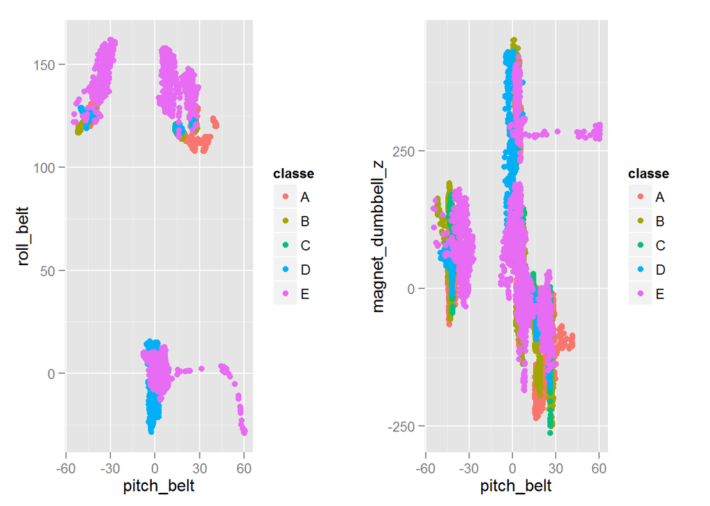

```r
plot1 <- qplot(pitch_belt,roll_belt,colour=classe,data=newtrain)
plot2 <- qplot(pitch_belt,magnet_dumbbell_z,colour=classe,data=newtrain)
grid.arrange(plot1,plot2,ncol=2)
```

## Expected Out of Sample Error

The following plots are very useful in evaluating the model.

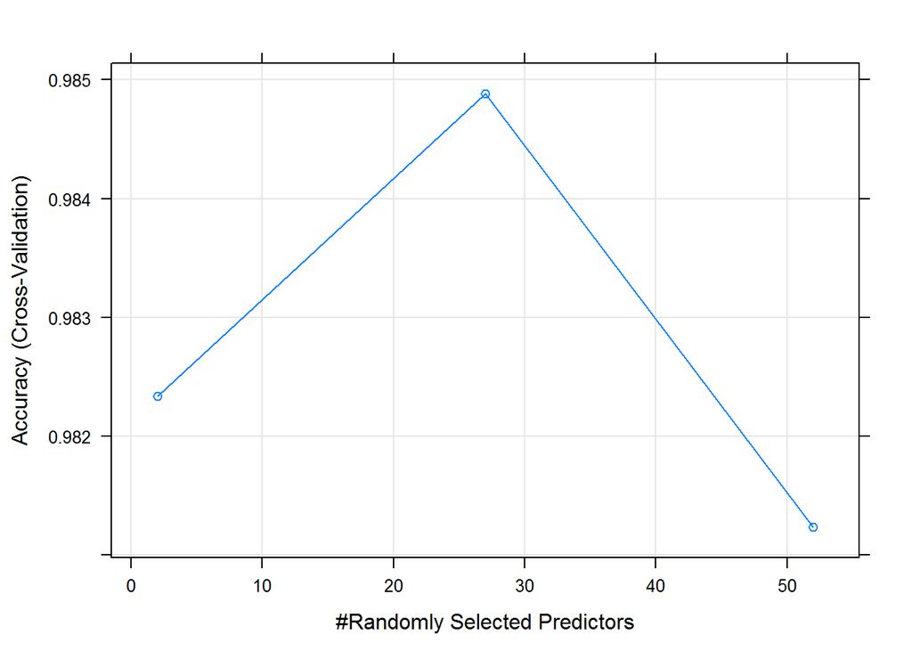

```r
plot(rf)
```

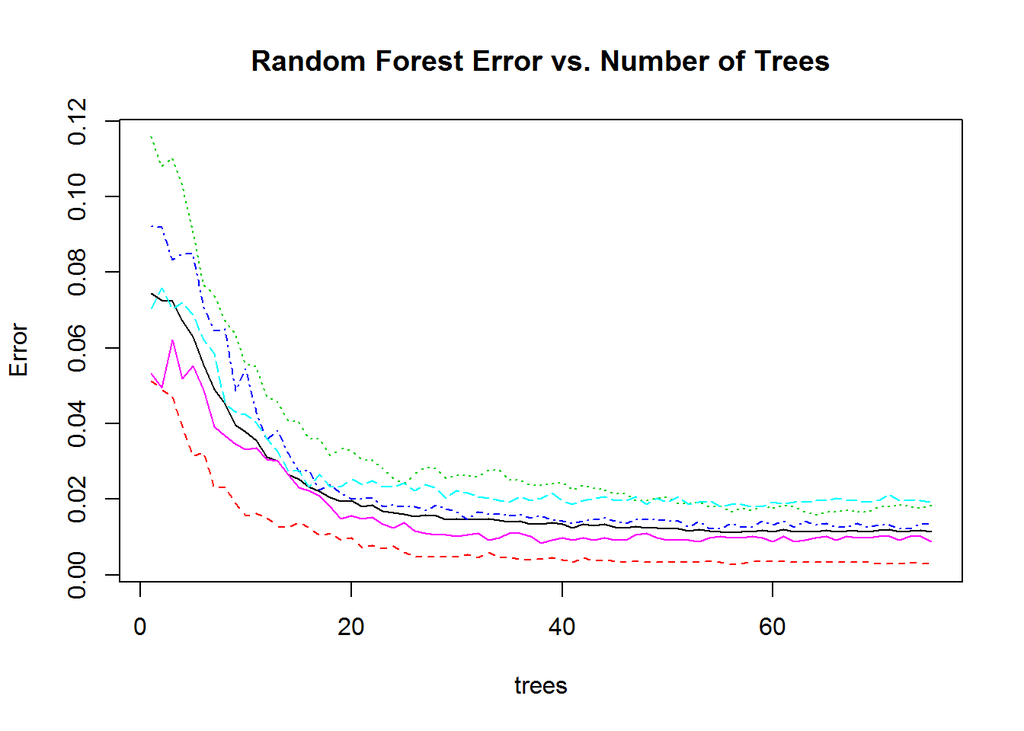

```r
plot(rf$finalModel, main="Random Forest Error vs. Number of Trees")
```

I now apply the same random forest model to the sub-test data and show the confusion matrix in order to estimate the out of sample error rate.

```r
pred <- predict(rf, newtest)
confusionMatrix(pred, newtest$classe)
```

```
## Confusion Matrix and Statistics
##
##           Reference
## Prediction    A    B    C    D    E
##          A 2224   13    0    1    0
##          B    8 1499    5    0    3
##          C    0    6 1358   20    3
##          D    0    0    5 1261    6
##          E    0    0    0    4 1430
##
## Overall Statistics
##
##                Accuracy : 0.9906
##                  95% CI : (0.9882, 0.9926)
##     No Information Rate : 0.2845
##     P-Value [Acc > NIR] : < 2.2e-16
##
##                   Kappa : 0.9881
##  Mcnemar's Test P-Value : NA
##
## Statistics by Class:
##
##                      Class: A Class: B Class: C Class: D Class: E
## Sensitivity            0.9964   0.9875   0.9927   0.9806   0.9917
## Specificity            0.9975   0.9975   0.9955   0.9983   0.9994
## Pos Pred Value         0.9937   0.9894   0.9791   0.9914   0.9972
## Neg Pred Value         0.9986   0.9970   0.9985   0.9962   0.9981
## Prevalence             0.2845   0.1935   0.1744   0.1639   0.1838
## Detection Rate         0.2835   0.1911   0.1731   0.1607   0.1823
## Detection Prevalence   0.2852   0.1931   0.1768   0.1621   0.1828
## Balanced Accuracy      0.9970   0.9925   0.9941   0.9894   0.9955
```

We can conclude that this random forest model is a **higly** predictive model with an estimated out of sample error rate of 1 - .9906 = **0.94%**.

The last step is to predict the outcomes of the 20 test cases in the holdout set (this is required as part of the project submission by Coursera). The model correctly predicts **all** outcomes.

```r
holdpred <- predict(rf,newdata=holdout)
holdpred <- as.character(holdpred)

pml_write_files <- function(x){
    n <- length(x)
    for(i in 1:n){
        filename <- paste0("problem_id_", i, ".txt")
        write.table(x[i], file=filename, quote=FALSE, row.names = FALSE, col.names = FALSE)
    }
}

# setwd("submission")
pml_write_files(holdpred)
```